# Week 9 Work

Arin Vansomphone

2022-08-17

# Tidymodels: Get Started Notes

### Build a model

Loading packages:

```r
library(tidymodels)
library(readr)
library(broom.mixed)
library(dotwhisker)
```

Loading data:

```r
urchins <- read_csv("https://tidymodels.org/start/models/urchins.csv") %>%
  setNames(c("food_regime", "initial_volume", "width")) %>%
  mutate(food_regime = factor(food_regime, levels = c("Initial", "Low",
                                                      "High")))
urchins
```

```
## # A tibble: 72 × 3
##    food_regime initial_volume width
##    <fct>                <dbl> <dbl>
##  1 Initial                3.5 0.01
##  2 Initial                5   0.02
##  3 Initial                8   0.061
##  4 Initial               10   0.051
##  5 Initial               13   0.041
##  6 Initial               13   0.061
##  7 Initial               15   0.041
##  8 Initial               15   0.071
##  9 Initial               16   0.092
## 10 Initial               17   0.051
## # … with 62 more rows
```

Plotting the data:

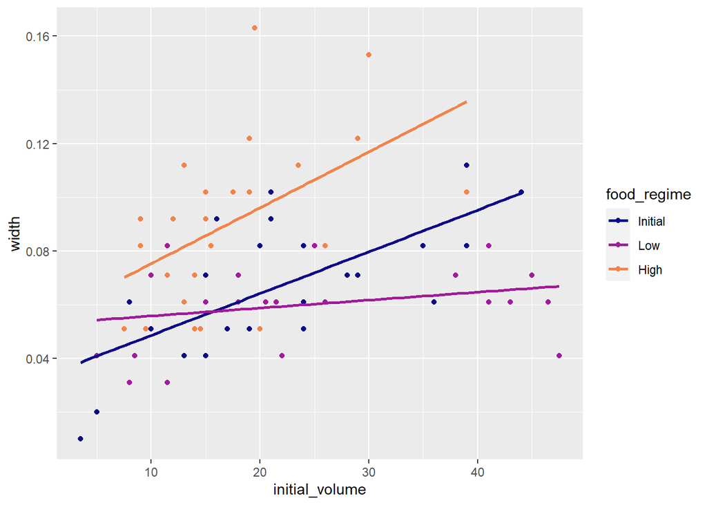

```r
ggplot(urchins,
       aes(x = initial_volume,
           y = width,
           group = food_regime,
           col = food_regime)) +
  geom_point() +
  geom_smooth(method = lm, se = FALSE) +
  scale_color_viridis_d(option = "plasma", end = .7)
```

- ANOVA models work best with a continuous variable and a categorical variable.

Specifying a formula for an ANOVA model:

```r
width ~ initial_volume * food_regime
```

```
## width ~ initial_volume * food_regime
```

Specifying the functional form:

```r
linear_reg()
```

```
## Linear Regression Model Specification (regression)
##
## Computational engine: lm
```

- The default linear regression option is `"lm"` for least squares. Check the `linear_reg()` documentation for more info.

Using the fit function:

```r
lm_mod <- linear_reg()
lm_fit <- lm_mod %>%
  fit(width ~ initial_volume * food_regime, data = urchins)
tidy(lm_fit) # tidying the output
```

```
## # A tibble: 6 × 5
##   term                            estimate std.error statistic  p.value
##   <chr>                              <dbl>     <dbl>     <dbl>    <dbl>
## 1 (Intercept)                     0.0331    0.00962      3.44  0.00100
## 2 initial_volume                  0.00155   0.000398     3.91  0.000222
## 3 food_regimeLow                  0.0198    0.0130       1.52  0.133
## 4 food_regimeHigh                 0.0214    0.0145       1.47  0.145
## 5 initial_volume:food_regimeLow  -0.00126   0.000510    -2.47  0.0162
## 6 initial_volume:food_regimeHigh  0.000525  0.000702     0.748 0.457
```

Plotting a dot and whisker plot of our regression results:

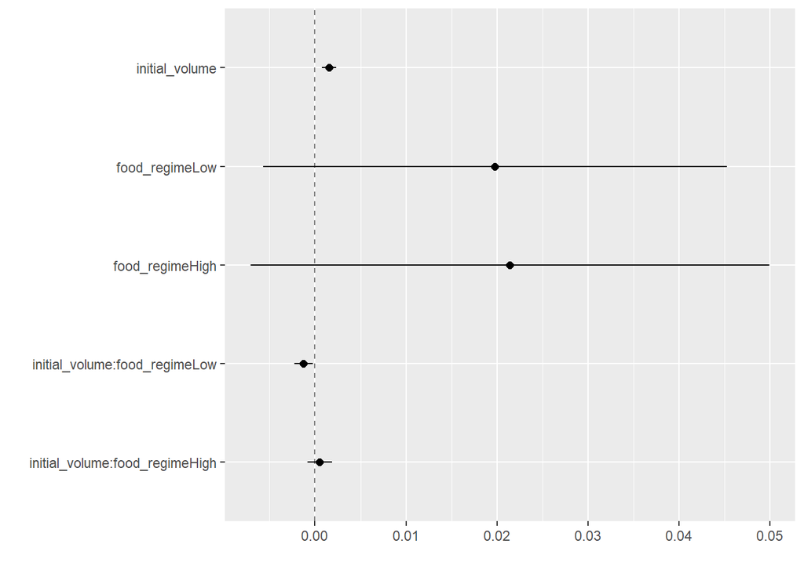

```r
tidy(lm_fit) %>%
  dwplot(dot_args = list(size = 2, color = "black"),
         whisker_args = list(color = "black"),
         vline = geom_vline(xintercept = 0, color = "grey50", linetype = 2))
```

Generating new data to make predictions for:

```r
new_points <- expand.grid(initial_volume = 20,
                          food_regime = c("Initial", "Low", "High"))
new_points
```

```
##   initial_volume food_regime
## 1             20     Initial
## 2             20         Low
## 3             20        High
```

Generating the mean body width values:

```r
mean_pred <- predict(lm_fit, new_data = new_points)
mean_pred
```

```
## # A tibble: 3 × 1
##    .pred
##    <dbl>
## 1 0.0642
## 2 0.0588
## 3 0.0961
```

Plotting a mean graph (with error bars) of predictions:

```r
conf_int_pred <- predict(lm_fit,
                         new_data = new_points,
                         type = "conf_int")
conf_int_pred
```

```
## # A tibble: 3 × 2
##   .pred_lower .pred_upper
##         <dbl>       <dbl>
## 1      0.0555      0.0729
## 2      0.0499      0.0678
## 3      0.0870      0.105
```

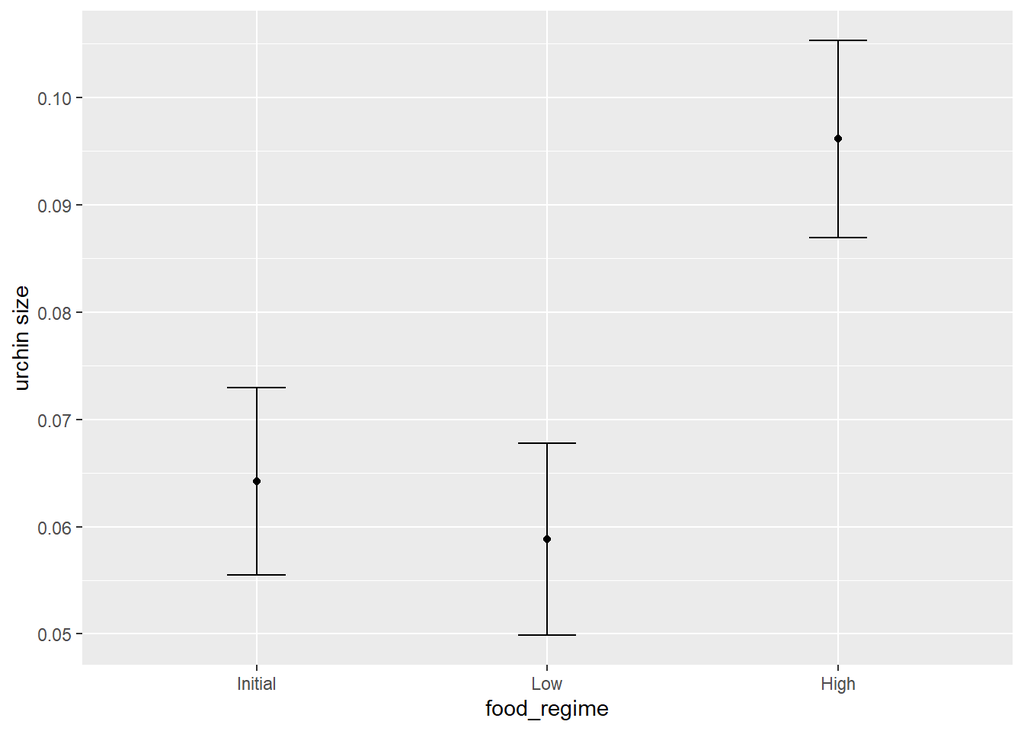

```r
plot_data <-
  new_points %>%
  bind_cols(mean_pred) %>%
  bind_cols(conf_int_pred)

ggplot(plot_data, aes(x = food_regime)) +
  geom_point(aes(y = .pred)) +
  geom_errorbar(aes(ymin = .pred_lower,
                    ymax = .pred_upper),
                width = .2) +
  labs(y = "urchin size")
```

A Bayesian analysis approach to modeling the data:

```r
library(rstanarm)
# set the prior distribution
prior_dist <- rstanarm::student_t(df = 1)

set.seed(123)

# make the parsnip model
bayes_mod <-
  linear_reg() %>%
  set_engine("stan",
             prior_intercept = prior_dist,
             prior = prior_dist)

# train the model
bayes_fit <-
  bayes_mod %>%
  fit(width ~ initial_volume * food_regime, data = urchins)

tidy(bayes_fit, conf.int = TRUE)
```

```
## # A tibble: 6 × 5
##   term                            estimate std.error  conf.low conf.high
##   <chr>                              <dbl>     <dbl>     <dbl>     <dbl>
## 1 (Intercept)                     0.0331    0.00943   0.0170    0.0493
## 2 initial_volume                  0.00155   0.000405  0.000891  0.00221
## 3 food_regimeLow                  0.0199    0.0133   -0.000262  0.0415
## 4 food_regimeHigh                 0.0216    0.0141   -0.00259   0.0461
## 5 initial_volume:food_regimeLow  -0.00126   0.000503 -0.00211  -0.000441
## 6 initial_volume:food_regimeHigh  0.000533  0.000700 -0.000685  0.00167
```

Plotting the Bayesian results:

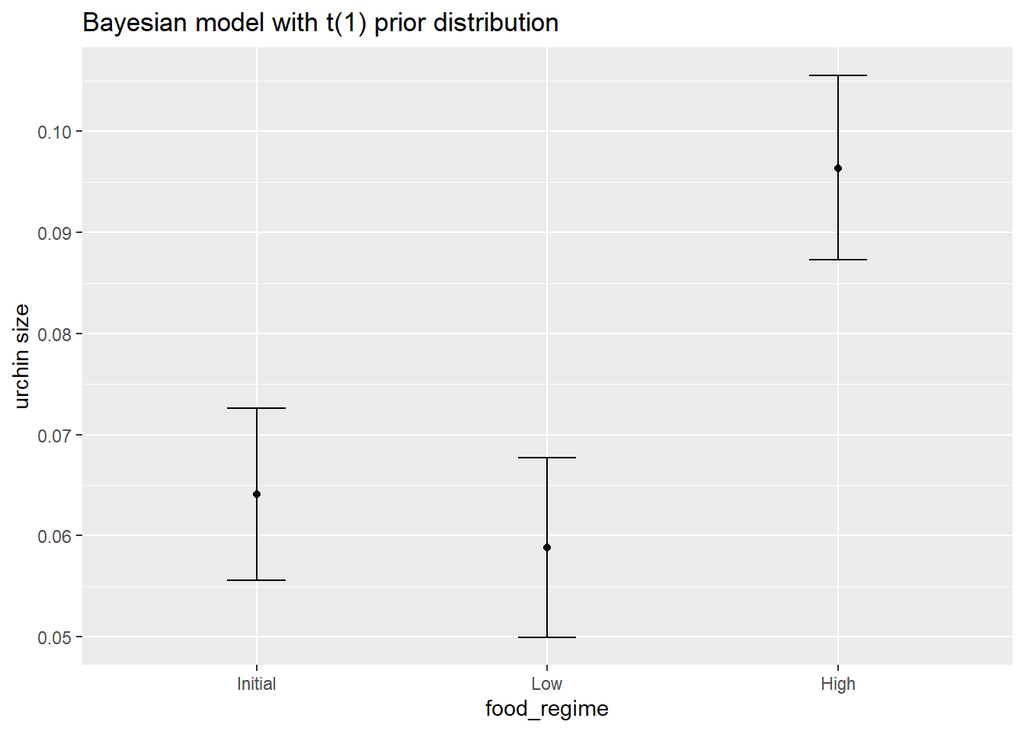

```r
bayes_plot_data <- new_points %>%
  bind_cols(predict(bayes_fit, new_data = new_points)) %>%
  bind_cols(predict(bayes_fit, new_data = new_points, type = "conf_int"))

ggplot(bayes_plot_data, aes(x = food_regime)) +
  geom_point(aes(y = .pred)) +
  geom_errorbar(aes(ymin = .pred_lower, ymax = .pred_upper), width = .2) +
  labs(y = "urchin size") +
  ggtitle("Bayesian model with t(1) prior distribution")
```

### Preprocess your data wit recipes

Loading packages:

```r
library(tidymodels)
library(nycflights13)
library(skimr)
```

Loading the data and modifying some variables:

```r
set.seed(123)

flight_data <- flights %>%
  mutate(
    arr_delay = ifelse(arr_delay >= 30, "late", "on_time"),
    arr_delay = factor(arr_delay),
    date = lubridate::as_date(time_hour)
  ) %>%
  inner_join(weather,by = c("origin", "time_hour")) %>%
  select(dep_time, flight, origin, dest, air_time, distance, carrier, date,
         arr_delay, time_hour) %>%
  na.omit() %>%
  mutate_if(is.character, as.factor) # character strings become factors
flight_data
```

```
## # A tibble: 325,819 × 10
##    dep_time flight origin dest  air_time distance carrier date       arr_delay
##       <int>  <int> <fct>  <fct>    <dbl>    <dbl> <fct>   <date>     <fct>
##  1      517   1545 EWR    IAH        227     1400 UA      2013-01-01 on_time
##  2      533   1714 LGA    IAH        227     1416 UA      2013-01-01 on_time
##  3      542   1141 JFK    MIA        160     1089 AA      2013-01-01 late
##  4      544    725 JFK    BQN        183     1576 B6      2013-01-01 on_time
##  5      554    461 LGA    ATL        116      762 DL      2013-01-01 on_time
##  6      554   1696 EWR    ORD        150      719 UA      2013-01-01 on_time
##  7      555    507 EWR    FLL        158     1065 B6      2013-01-01 on_time
##  8      557   5708 LGA    IAD         53      229 EV      2013-01-01 on_time
##  9      557     79 JFK    MCO        140      944 B6      2013-01-01 on_time
## 10      558    301 LGA    ORD        138      733 AA      2013-01-01 on_time
## # … with 325,809 more rows, and 1 more variable: time_hour <dttm>
```

Splitting the data into a training and testing set:

```r
library(rsample)
set.seed(222) # this enables reproducibility in random number generation

#put 3/4 of the data into the training set
data_split <- initial_split(flight_data, prop = 3/4)

train_data <- training(data_split)
test_data <- testing(data_split)
```

Creating the recipe:

```r
flights_rec <-
  recipe(arr_delay ~ ., data = train_data) %>%
  update_role(flight, time_hour, new_role = "ID") %>%
  step_date(date, features = c("dow", "month")) %>%
  step_holiday(date,
               holidays = timeDate::listHolidays("US"),
               keep_original_cols = FALSE) %>%
  step_dummy(all_nominal_predictors()) %>%
  step_zv(all_predictors())
summary(flights_rec)
```

```
## # A tibble: 10 × 4
##    variable  type    role      source
##    <chr>     <chr>   <chr>     <chr>
##  1 dep_time  numeric predictor original
##  2 flight    numeric ID        original
##  3 origin    nominal predictor original
##  4 dest      nominal predictor original
##  5 air_time  numeric predictor original
##  6 distance  numeric predictor original
##  7 carrier   nominal predictor original
##  8 date      date    predictor original
##  9 time_hour date    ID        original
## 10 arr_delay nominal outcome   original
```

Model specification:

```r
lr_mod <- logistic_reg() %>%
  set_engine("glm")
```

Bundle the model and recipe with data:

```r
flights_wflow <- workflow() %>%
  add_model(lr_mod) %>%
  add_recipe(flights_rec)

flights_wflow
```

```
## ══ Workflow ════════════════════════════════════════════════════════════════════
## Preprocessor: Recipe
## Model: logistic_reg()
##
## ── Preprocessor ────────────────────────────────────────────────────────────────
## 4 Recipe Steps
##
## • step_date()
## • step_holiday()
## • step_dummy()
## • step_zv()
##
## ── Model ───────────────────────────────────────────────────────────────────────
## Logistic Regression Model Specification (classification)
##
## Computational engine: glm
```

Training the model!

```r
flights_fit <- flights_wflow %>%
  fit(data = train_data)
```

```r
flights_fit %>%
  extract_fit_parsnip() %>%
  tidy()
```

```
## # A tibble: 157 × 5
##    term                         estimate std.error statistic  p.value
##    <chr>                           <dbl>     <dbl>     <dbl>    <dbl>
##  1 (Intercept)                   7.28    2.73           2.67 7.64e- 3
##  2 dep_time                     -0.00166 0.0000141   -118.   0
##  3 air_time                     -0.0440  0.000563     -78.2  0
##  4 distance                      0.00507 0.00150        3.38 7.32e- 4
##  5 date_USChristmasDay           1.33    0.177          7.49 6.93e-14
##  6 date_USColumbusDay            0.724   0.170          4.25 2.13e- 5
##  7 date_USCPulaskisBirthday      0.807   0.139          5.80 6.57e- 9
##  8 date_USDecorationMemorialDay  0.585   0.117          4.98 6.32e- 7
##  9 date_USElectionDay            0.948   0.190          4.98 6.25e- 7
## 10 date_USGoodFriday             1.25    0.167          7.45 9.40e-14
## # … with 147 more rows
```

Running our model through the test data:

```r
flights_aug <- augment(flights_fit, test_data)

flights_aug %>%
  select(arr_delay, time_hour, flight, .pred_class, .pred_on_time)
```

```
## # A tibble: 81,455 × 5
##    arr_delay time_hour           flight .pred_class .pred_on_time
##    <fct>     <dttm>               <int> <fct>               <dbl>
##  1 on_time   2013-01-01 05:00:00   1545 on_time             0.945
##  2 on_time   2013-01-01 05:00:00   1714 on_time             0.949
##  3 on_time   2013-01-01 06:00:00    507 on_time             0.964
##  4 on_time   2013-01-01 06:00:00   5708 on_time             0.961
##  5 on_time   2013-01-01 06:00:00     71 on_time             0.962
##  6 on_time   2013-01-01 06:00:00    194 on_time             0.975
##  7 on_time   2013-01-01 06:00:00   1124 on_time             0.963
##  8 on_time   2013-01-01 05:00:00   1806 on_time             0.981
##  9 on_time   2013-01-01 06:00:00   1187 on_time             0.935
## 10 on_time   2013-01-01 06:00:00   4650 on_time             0.931
## # … with 81,445 more rows
```

Creating an ROC curve:

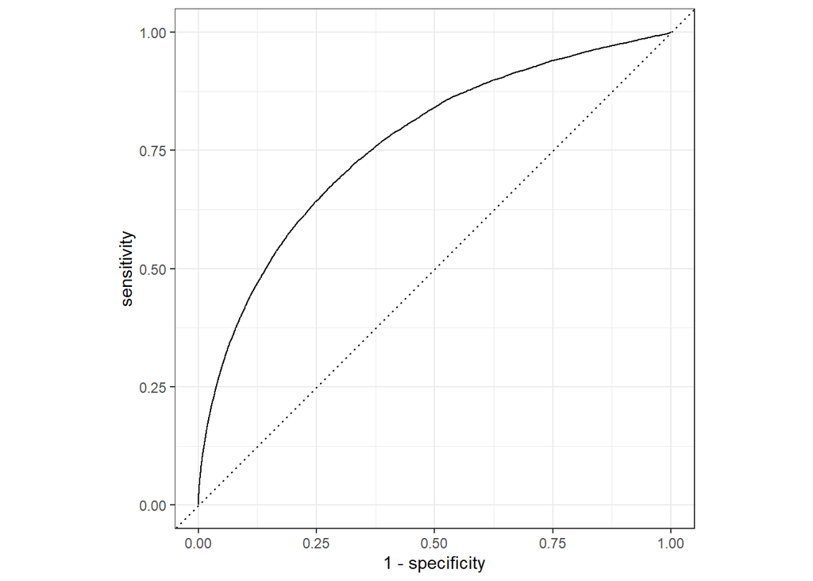

```r
flights_aug %>%
  roc_curve(truth = arr_delay, .pred_late) %>%
  autoplot()
```

Estimating the area under the curve:

```r
flights_aug %>%
  roc_auc(truth = arr_delay, .pred_late)
```

```
## # A tibble: 1 × 3
##   .metric .estimator .estimate
##   <chr>   <chr>          <dbl>
## 1 roc_auc binary         0.764
```

### Evaluate your model with resampling

Loading packages:

```r
library(tidymodels)
library(modeldata)
```

Loading data:

```r
data(cells, package = "modeldata")
cells
```

```
## # A tibble: 2,019 × 58
##    case  class angle_ch_1 area_ch_1 avg_inten_ch_1 avg_inten_ch_2 avg_inten_ch_3
##    <fct> <fct>      <dbl>     <int>          <dbl>          <dbl>          <dbl>
##  1 Test  PS        143.         185           15.7           4.95           9.55
##  2 Train PS        134.         819           31.9         207.            69.9
##  3 Train WS        107.         431           28.0         116.            63.9
##  4 Train PS         69.2        298           19.5         102.            28.2
##  5 Test  PS          2.89       285           24.3         112.            20.5
##  6 Test  WS         40.7        172          326.          654.           129.
##  7 Test  WS        174.         177          260.          596.           124.
##  8 Test  PS        180.         251           18.3           5.73          17.2
##  9 Test  WS         18.9        495           16.1          89.5           13.7
## 10 Test  WS        153.         384           17.7          89.9           20.4
## # … with 2,009 more rows, and 51 more variables: avg_inten_ch_4 <dbl>,
## #   convex_hull_area_ratio_ch_1 <dbl>, convex_hull_perim_ratio_ch_1 <dbl>,
## #   diff_inten_density_ch_1 <dbl>, diff_inten_density_ch_3 <dbl>,
## #   diff_inten_density_ch_4 <dbl>, entropy_inten_ch_1 <dbl>,
## #   entropy_inten_ch_3 <dbl>, entropy_inten_ch_4 <dbl>,
## #   eq_circ_diam_ch_1 <dbl>, eq_ellipse_lwr_ch_1 <dbl>,
## #   eq_ellipse_oblate_vol_ch_1 <dbl>, eq_ellipse_prolate_vol_ch_1 <dbl>, …
```

Removing the `case` variable to make our own split:

```r
set.seed(123)
cell_split <- initial_split(cells %>% select(-case),
                            strata = class) # stratified split
```

Train and test datasets:

```r
cell_train <- training(cell_split)
cell_test <- testing(cell_split)

cell_train %>%
  count(class) %>%
  mutate(prop = n/sum(n))
```

```
## # A tibble: 2 × 3
##   class     n  prop
##   <fct> <int> <dbl>
## 1 PS      975 0.644
## 2 WS      539 0.356
```

Creating a random forest model:

```r
rf_mod <- rand_forest(trees = 1000) %>%
  set_engine("ranger") %>%
  set_mode("classification")
```

Using the fit function:

```r
library(ranger)
set.seed(234)
rf_fit <- rf_mod %>%
  fit(class ~., data = cell_train)
rf_fit
```

```
## parsnip model object
##
## Ranger result
##
## Call:
##  ranger::ranger(x = maybe_data_frame(x), y = y, num.trees = ~1000,      num.threads = 1, verbose = FALSE, seed = sample.int(10^5,          1), probability = TRUE)
##
## Type:                             Probability estimation
## Number of trees:                  1000
## Sample size:                      1514
## Number of independent variables:  56
## Mtry:                             7
## Target node size:                 10
## Variable importance mode:         none
## Splitrule:                        gini
## OOB prediction error (Brier s.):  0.1187479
```

Computing the area under ROC curve and overall accuracy (DO NOT DO IT ON TRAINING SET):

```r
rf_testing_pred <-
  predict(rf_fit, cell_test) %>%
  bind_cols(predict(rf_fit, cell_test, type = "prob")) %>%
  bind_cols(cell_test %>% select(class))
```

```r
rf_testing_pred %>%
  roc_auc(truth = class, .pred_PS)
```

```
## # A tibble: 1 × 3
##   .metric .estimator .estimate
##   <chr>   <chr>          <dbl>
## 1 roc_auc binary         0.891
```

```r
rf_testing_pred %>%
  accuracy(truth = class, .pred_class)
```

```
## # A tibble: 1 × 3
##   .metric  .estimator .estimate
##   <chr>    <chr>          <dbl>
## 1 accuracy binary         0.814
```

Resampling methods create series of data sets similar to the training/testing set.

Generating cross-validation resampling:

```r
set.seed(345)
folds <- vfold_cv(cell_train, v = 10)
folds
```

```
## #  10-fold cross-validation
## # A tibble: 10 × 2
##    splits             id
##    <list>             <chr>
##  1 <split [1362/152]> Fold01
##  2 <split [1362/152]> Fold02
##  3 <split [1362/152]> Fold03
##  4 <split [1362/152]> Fold04
##  5 <split [1363/151]> Fold05
##  6 <split [1363/151]> Fold06
##  7 <split [1363/151]> Fold07
##  8 <split [1363/151]> Fold08
##  9 <split [1363/151]> Fold09
## 10 <split [1363/151]> Fold10
```

Resampling via the workflow:

```r
rf_wf <-
  workflow() %>%
  add_model(rf_mod) %>%
  add_formula(class ~ .)

set.seed(456)
rf_fit_rs <-
  rf_wf %>%
  fit_resamples(folds)
rf_fit_rs
```

```
## # Resampling results
## # 10-fold cross-validation
## # A tibble: 10 × 4
##    splits             id     .metrics         .notes
##    <list>             <chr>  <list>           <list>
##  1 <split [1362/152]> Fold01 <tibble [2 × 4]> <tibble [0 × 3]>
##  2 <split [1362/152]> Fold02 <tibble [2 × 4]> <tibble [0 × 3]>
##  3 <split [1362/152]> Fold03 <tibble [2 × 4]> <tibble [0 × 3]>
##  4 <split [1362/152]> Fold04 <tibble [2 × 4]> <tibble [0 × 3]>
##  5 <split [1363/151]> Fold05 <tibble [2 × 4]> <tibble [0 × 3]>
##  6 <split [1363/151]> Fold06 <tibble [2 × 4]> <tibble [0 × 3]>
##  7 <split [1363/151]> Fold07 <tibble [2 × 4]> <tibble [0 × 3]>
##  8 <split [1363/151]> Fold08 <tibble [2 × 4]> <tibble [0 × 3]>
##  9 <split [1363/151]> Fold09 <tibble [2 × 4]> <tibble [0 × 3]>
## 10 <split [1363/151]> Fold10 <tibble [2 × 4]> <tibble [0 × 3]>
```

Accuracy with `collect_metrics`:

```r
collect_metrics(rf_fit_rs)
```

```
## # A tibble: 2 × 6
##   .metric  .estimator  mean     n std_err .config
##   <chr>    <chr>      <dbl> <int>   <dbl> <chr>
## 1 accuracy binary     0.833    10 0.00876 Preprocessor1_Model1
## 2 roc_auc  binary     0.905    10 0.00627 Preprocessor1_Model1
```

# Tidymodels in the 1,5 AG Project